# ExtraaLearn Project

## 1 Context

The EdTech industry has been surging in the past decade immensely, and according to a forecast, the Online Education market would be worth $286.62bn by 2023 with a compound annual growth rate (CAGR) of 10.26% from 2018 to 2023. The modern era of online education has enforced a lot in its growth and expansion beyond any limit. Due to having many dominant features like ease of information sharing, personalized learning experience, transparency of assessment, etc, it is now preferable to traditional education.

In the present scenario due to the Covid-19, the online education sector has witnessed rapid growth and is attracting a lot of new customers. Due to this rapid growth, many new companies have emerged in this industry. With the availability and ease of use of digital marketing resources, companies can reach out to a wider audience with their offerings. The customers who show interest in these offerings are termed as leads. There are various sources of obtaining leads for Edtech companies, like

- The customer interacts with the marketing front on social media or other online platforms.
- The customer browses the website/app and downloads the brochure
- The customer connects through emails for more information.

The company then nurtures these leads and tries to convert them to paid customers. For this, the representative from the organization connects with the lead on call or through email to share further details.

### Objective

ExtraaLearn is an initial stage startup that offers programs on cutting-edge technologies to students and professionals to help them upskill/reskill. With a large number of leads being generated on a regular basis, one of the issues faced by ExtraaLearn is to identify which of the leads are more likely to convert so that they can allocate resources accordingly. You, as a data scientist at ExtraaLearn, have been provided the leads data to:

- Analyze and build an ML model to help identify which leads are more likely to convert to paid customers,
- Find the factors driving the lead conversion process
- Create a profile of the leads which are likely to convert

### Data Description

The data contains the different attributes of leads and their interaction details with ExtraaLearn. The detailed data dictionary is given below.

**Data Dictionary**

- ID: ID of the lead
- age: Age of the lead
- current_occupation: Current occupation of the lead. Values include 'Professional','Unemployed',and 'Student'
- first_interaction: How did the lead first interacted with ExtraaLearn. Values include 'Website', 'Mobile App'
- profile_completed: What percentage of profile has been filled by the lead on the website/mobile app. Values include Low - (0-50%), Medium - (50-75%), High (75-100%)
- website_visits: How many times has a lead visited the website
- time_spent_on_website: Total time spent on the website
- page_views_per_visit: Average number of pages on the website viewed during the visits.
- last_activity: Last interaction between the lead and ExtraaLearn.
  - Email Activity: Seeking for details about program through email, Representative shared information with lead like brochure of program , etc
  - Phone Activity: Had a Phone Conversation with representative, Had conversation over SMS with representative, etc
  - Website Activity: Interacted on live chat with representative, Updated profile on website, etc
- print_media_type1: Flag indicating whether the lead had seen the ad of ExtraaLearn in the Newspaper.
- print_media_type2: Flag indicating whether the lead had seen the ad of ExtraaLearn in the Magazine.
- digital_media: Flag indicating whether the lead had seen the ad of ExtraaLearn on the digital platforms.
- educational_channels: Flag indicating whether the lead had heard about ExtraaLearn in the education channels like online forums, discussion threads, educational websites, etc.
- referral: Flag indicating whether the lead had heard about ExtraaLearn through reference.
- status: Flag indicating whether the lead was converted to a paid customer or not.

## 2 Importing necessary libraries and data

```python
import pandas as pd
import numpy as np
import matplotlib.pyplot as plt
import seaborn as sns
# %matplotlib inline  # (for Jupyter Notebook)
from sklearn.preprocessing import LabelEncoder, StandardScaler
from sklearn.model_selection import train_test_split, GridSearchCV
from sklearn.tree import DecisionTreeClassifier
from sklearn.ensemble import RandomForestClassifier
from sklearn.metrics import classification_report, confusion_matrix, roc_auc_score, accuracy_score
```

## 3 Data Overview

- Observations
- Sanity checks

### Load the Dataset

```python
df = pd.read_csv('ExtraaLearn.csv')
```

### Shape and Info

```python
# Shape of the dataset
print("Shape of the dataset:", df.shape)

# Basic info: data types and non-null counts
df.info()
```

```
Shape of the dataset: (4612, 15)
<class 'pandas.core.frame.DataFrame'>
RangeIndex: 4612 entries, 0 to 4611
Data columns (total 15 columns):
 #   Column                 Non-Null Count  Dtype
---  ------                 --------------  -----
 0   ID                     4612 non-null   object
 1   age                    4612 non-null   int64
 2   current_occupation     4612 non-null   object
 3   first_interaction      4612 non-null   object
 4   profile_completed      4612 non-null   object
 5   website_visits         4612 non-null   int64
 6   time_spent_on_website  4612 non-null   int64
 7   page_views_per_visit   4612 non-null   float64
 8   last_activity          4612 non-null   object
 9   print_media_type1      4612 non-null   object
 10  print_media_type2      4612 non-null   object
 11  digital_media          4612 non-null   object
 12  educational_channels   4612 non-null   object
 13  referral               4612 non-null   object
 14  status                 4612 non-null   int64
dtypes: float64(1), int64(4), object(10)
memory usage: 540.6+ KB
```

### Descriptive Statistics

```python
# Summary statistics for numerical columns
df.describe()
```

|  | age | website_visits | time_spent_on_website | page_views_per_visit | status |
| --- | --- | --- | --- | --- | --- |
| count | 4612.000000 | 4612.000000 | 4612.000000 | 4612.000000 | 4612.000000 |
| mean | 46.201214 | 3.566782 | 724.011275 | 3.026126 | 0.298569 |
| std | 13.161454 | 2.829134 | 743.828683 | 1.968125 | 0.457680 |
| min | 18.000000 | 0.000000 | 0.000000 | 0.000000 | 0.000000 |
| 25% | 36.000000 | 2.000000 | 148.750000 | 2.077750 | 0.000000 |
| 50% | 51.000000 | 3.000000 | 376.000000 | 2.792000 | 0.000000 |
| 75% | 57.000000 | 5.000000 | 1336.750000 | 3.756250 | 1.000000 |
| max | 63.000000 | 30.000000 | 2537.000000 | 18.434000 | 1.000000 |

### Null Value Check

```python
# Total missing values per column
df.isnull().sum()
```

```
ID                       0
age                      0
current_occupation       0
first_interaction        0
profile_completed        0
website_visits           0
time_spent_on_website    0
page_views_per_visit     0
last_activity            0
print_media_type1        0
print_media_type2        0
digital_media            0
educational_channels     0
referral                 0
status                   0
dtype: int64
```

### Target Variable Distribution

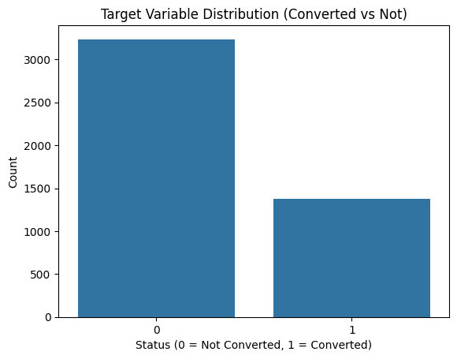

```
status
0    0.701431
1    0.298569
Name: proportion, dtype: float64
```

```python
# Distribution of target variable (status)
sns.countplot(x='status', data=df)
plt.title("Target Variable Distribution (Converted vs Not)")
plt.xlabel("Status (0 = Not Converted, 1 = Converted)")
plt.ylabel("Count")
plt.show()

# Print class distribution
df['status'].value_counts(normalize=True)
```

## 4 Exploratory Data Analysis (EDA)

- EDA is an important part of any project involving data.
- It is important to investigate and understand the data better before building a model with it.
- A few questions have been mentioned below which will help you approach the analysis in the right manner and generate insights from the data.
- A thorough analysis of the data, in addition to the questions mentioned below, should be done.

**Questions**

1. Leads will have different expectations from the outcome of the course and the current occupation may play a key role in getting them to participate in the program. Find out how current occupation affects lead status.
2. The company's first impression on the customer must have an impact. Do the first channels of interaction have an impact on the lead status?
3. The company uses multiple modes to interact with prospects. Which way of interaction works best?
4. The company gets leads from various channels such as print media, digital media, referrals, etc. Which of these channels have the highest lead conversion rate?
5. People browsing the website or mobile application are generally required to create a profile by sharing their personal data before they can access additional information.Does having more details about a prospect increase the chances of conversion?

### Univariate Analysis

#### Target Variable

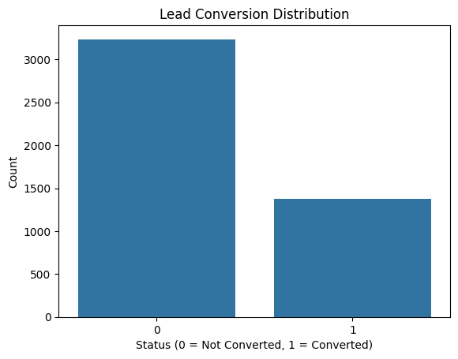

```
status
0    0.701431
1    0.298569
Name: proportion, dtype: float64
```

```python
sns.countplot(x='status', data=df)
plt.title("Lead Conversion Distribution")
plt.xlabel("Status (0 = Not Converted, 1 = Converted)")
plt.ylabel("Count")
plt.show()

print(df['status'].value_counts(normalize=True))
```

#### Numerical Features

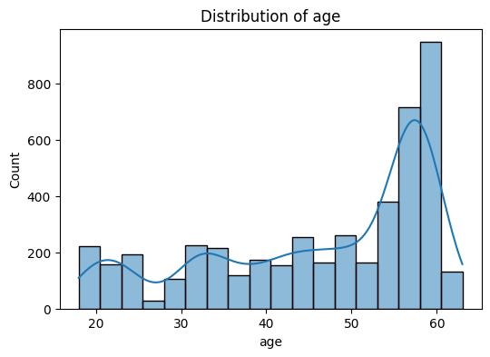

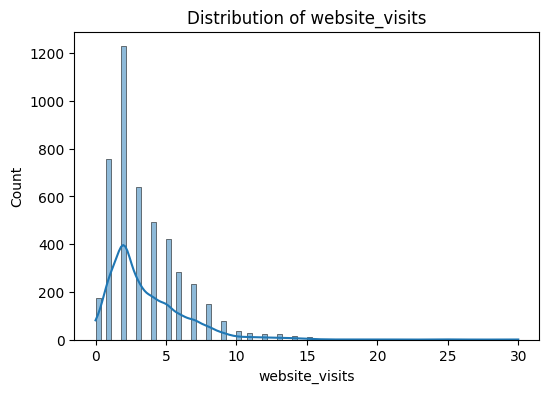

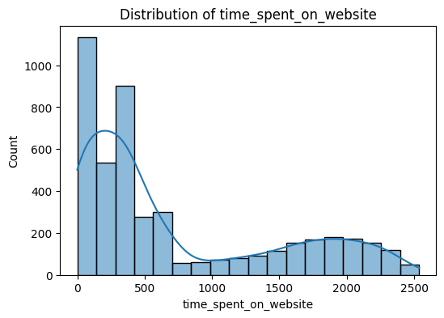

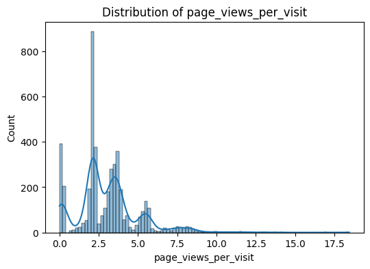

```python
numerical_cols = ['age', 'website_visits', 'time_spent_on_website', 'page_views_per_visit']

for col in numerical_cols:
    plt.figure(figsize=(6, 4))
    sns.histplot(df[col], kde=True)
    plt.title(f"Distribution of {col}")
    plt.show()
```

#### Categorical Features

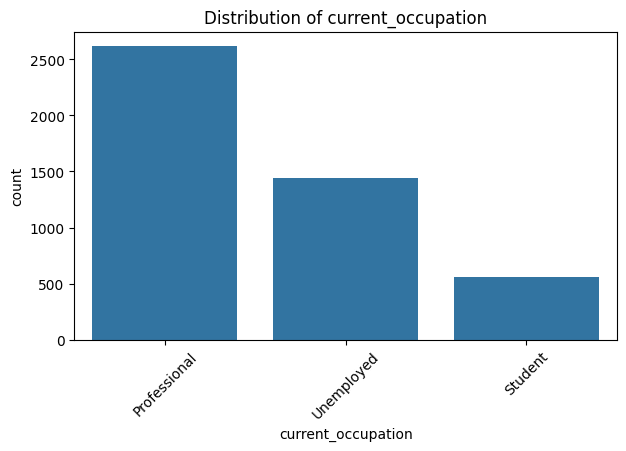

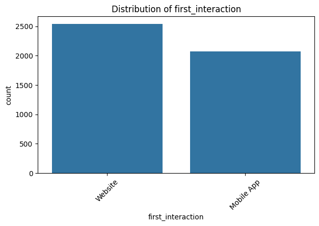

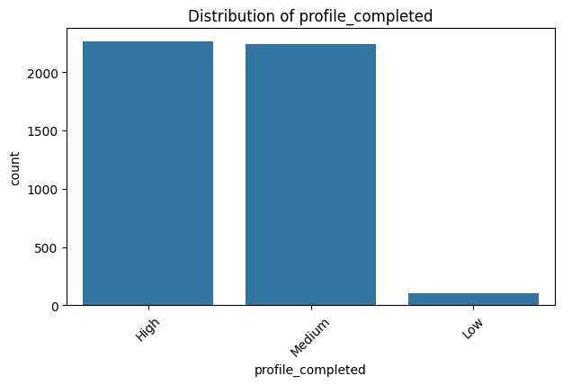

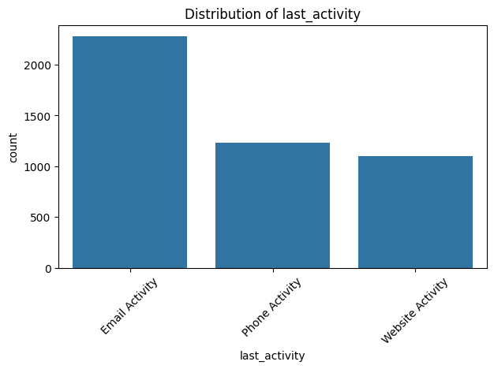

```python
categorical_cols = ['current_occupation', 'first_interaction', 'profile_completed', 'last_activity']

for col in categorical_cols:
    plt.figure(figsize=(7, 4))
    sns.countplot(data=df, x=col, order=df[col].value_counts().index)
    plt.title(f"Distribution of {col}")
    plt.xticks(rotation=45)
    plt.show()
```

### Bivariate Analysis (vs Target)

#### Numeric Features vs status

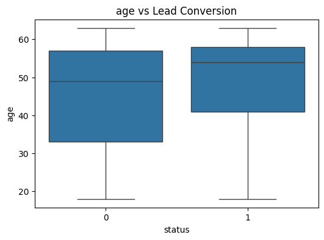

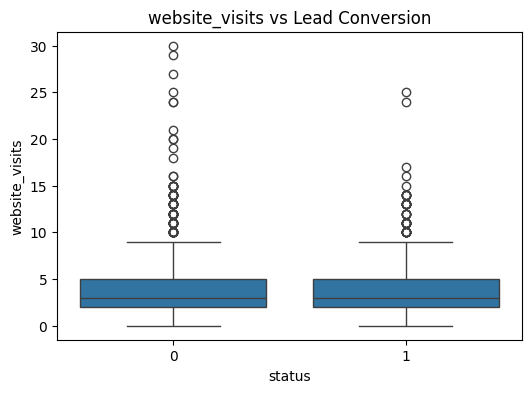

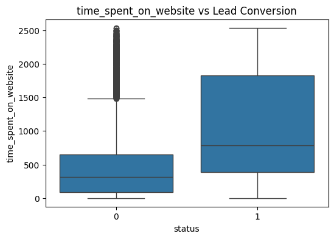

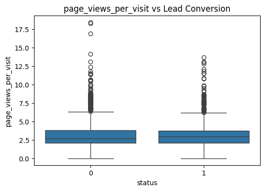

```python
for col in numerical_cols:
    plt.figure(figsize=(6, 4))
    sns.boxplot(x='status', y=col, data=df)
    plt.title(f"{col} vs Lead Conversion")
    plt.show()
```

#### Categorical Features vs status

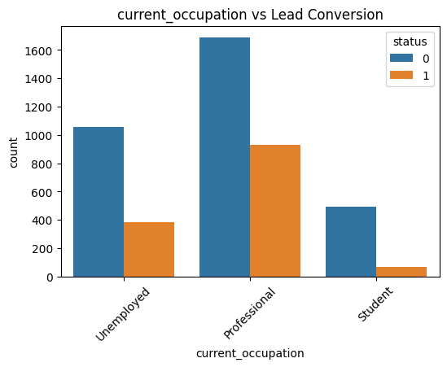

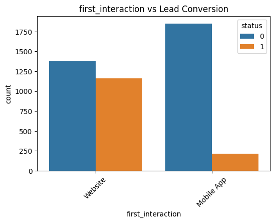

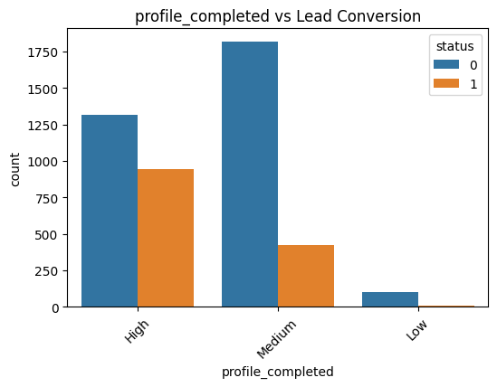

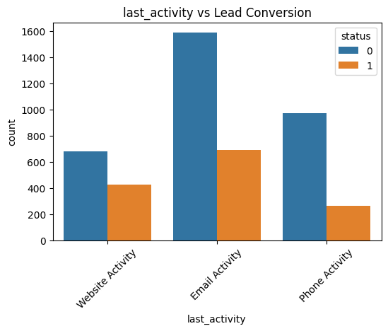

```python
for col in categorical_cols:
    plt.figure(figsize=(6, 4))
    sns.countplot(data=df, x=col, hue='status')
    plt.title(f"{col} vs Lead Conversion")
    plt.xticks(rotation=45)
    plt.show()
```

## 5 Data Preprocessing

#### Drop Irrelevant Columns

```python
df = df.drop(columns=['ID'])  # Not predictive
```

#### Handle Missing Values

```python
# Check nulls
df.isnull().sum()

# If minimal, drop rows with missing values
#df = df.dropna()

# OR (example): fill missing age with median
# df['age'].fillna(df['age'].median(), inplace=True)
```

```
age                      0
current_occupation       0
first_interaction        0
profile_completed        0
website_visits           0
time_spent_on_website    0
page_views_per_visit     0
last_activity            0
print_media_type1        0
print_media_type2        0
digital_media            0
educational_channels     0
referral                 0
status                   0
dtype: int64
```

#### Encode Categorical Variables

##### Ordinal: profile_completed

```python
profile_map = {'Low': 0, 'Medium': 1, 'High': 2}
df['profile_completed'] = df['profile_completed'].map(profile_map)
```

```python
profile_map = {'Low': 0, 'Medium': 1, 'High': 2}
df['profile_completed'] = df['profile_completed'].map(profile_map)
```

##### Nominal: One-hot encoding

```python
df = pd.get_dummies(df, columns=['current_occupation', 'first_interaction', 'last_activity'], drop_first=True)
```

#### Feature Engineering

```python
# New feature: engagement score
df['engagement_score'] = df['website_visits'] * df['page_views_per_visit']
```

Created engagement_score to combine volume and depth of interaction.

#### Train-Test Split

```python
X = df.drop(columns=['status'])
y = df['status']

X_train, X_test, y_train, y_test = train_test_split(X, y, test_size=0.2, stratify=y, random_state=42)
```

Used stratified sampling to preserve class balance during train-test split.

## 6 Building a Decision Tree Model

### Train the Model

```python
#Identify Non-Numeric Columns
X.select_dtypes(include='object').columns

#Convert Yes/No to Binary
yes_no_cols = ['print_media_type1', 'print_media_type2', 'digital_media', 'educational_channels', 'referral']

for col in yes_no_cols:
    df[col] = df[col].map({'Yes': 1, 'No': 0})

#Train-Test Split
X = df.drop(columns=['status'])
y = df['status']
X_train, X_test, y_train, y_test = train_test_split(X, y, test_size=0.2, stratify=y, random_state=42)
```

```python
dt_model = DecisionTreeClassifier(random_state=42)
dt_model.fit(X_train, y_train)
```

```
DecisionTreeClassifier(random_state=42)
```

#### Predict and Evaluate

```
Decision Tree - Classification Report:
              precision    recall  f1-score   support

           0       0.81      0.83      0.82       647
           1       0.58      0.54      0.56       276

    accuracy                           0.74       923
   macro avg       0.69      0.68      0.69       923
weighted avg       0.74      0.74      0.74       923

Confusion Matrix:
```

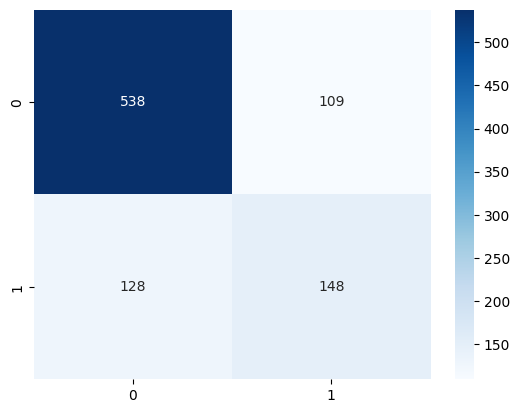

```
ROC AUC Score: 0.683881011580763
```

```python
y_pred_dt = dt_model.predict(X_test)

# Evaluation metrics
print("Decision Tree - Classification Report:")
print(classification_report(y_test, y_pred_dt))

print("Confusion Matrix:")
sns.heatmap(confusion_matrix(y_test, y_pred_dt), annot=True, fmt='d', cmap='Blues')
plt.show()

# ROC-AUC
roc_dt = roc_auc_score(y_test, y_pred_dt)
print("ROC AUC Score:", roc_dt)
```

#### Decision Tree

The model achieves an overall accuracy of 74%, which is a moderate baseline performance.

The ROC AUC score of 0.68 indicates a limited ability to distinguish between leads that convert and those that don’t.

##### Class-wise Performance:

Class 0 (Not Converted):

Precision: 81%, Recall: 83% — the model is reasonably good at detecting non-converting leads.

Class 1 (Converted):

Precision: 58%, Recall: 54% — the model struggles to identify converting leads, missing nearly half of them.

##### Confusion Matrix Insights:

False Negatives (128): A large number of actual conversions are being missed — a significant business risk.

False Positives (109): Many non-converting leads are incorrectly predicted as converters, leading to inefficient resource allocation.

##### Conclusion:

The model appears to overfit to the dominant class and lacks generalization capability.

These results suggest that pruning the tree or using ensemble methods like Random Forest may help improve both precision and recall for the minority class (converted leads).

## 7 Do we need to prune the tree?

#### Evaluate Overfitting Risk

By default, the Decision Tree may overfit due to deep splits. We'll evaluate accuracy at different max_depth values to check for potential pruning.

#### Accuracy vs Max Depth

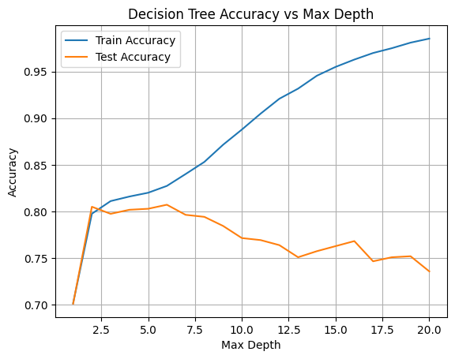

```python
train_accuracies = []
test_accuracies = []
depth_range = range(1, 21)

for d in depth_range:
    model = DecisionTreeClassifier(max_depth=d, random_state=42)
    model.fit(X_train, y_train)
    train_accuracies.append(model.score(X_train, y_train))
    test_accuracies.append(model.score(X_test, y_test))

plt.plot(depth_range, train_accuracies, label='Train Accuracy')
plt.plot(depth_range, test_accuracies, label='Test Accuracy')
plt.xlabel('Max Depth')
plt.ylabel('Accuracy')
plt.title('Decision Tree Accuracy vs Max Depth')
plt.legend()
plt.grid(True)
plt.show()
```

The graph shows that training accuracy steadily increases with tree depth, reaching near-perfect accuracy at depth 20 — clear sign of overfitting.

This confirms that the model starts memorizing the training data instead of generalizing to unseen data beyond this point.

Conclusion: The Decision Tree overfits after depth 6.

We will prune the tree by setting max_depth=5 in the next step to improve generalization and prevent overfitting.

#### Train Pruned Decision Tree (max_depth=5)

```
Pruned Decision Tree - Classification Report:
              precision    recall  f1-score   support

           0       0.82      0.92      0.87       647
           1       0.74      0.53      0.62       276

    accuracy                           0.80       923
   macro avg       0.78      0.72      0.74       923
weighted avg       0.80      0.80      0.79       923
```

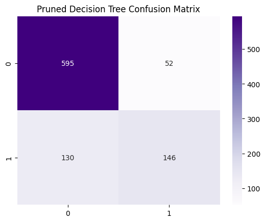

```
ROC AUC Score: 0.7243072822166969
```

```python
pruned_tree = DecisionTreeClassifier(max_depth=5, random_state=42)
pruned_tree.fit(X_train, y_train)

y_pred_pruned = pruned_tree.predict(X_test)

# Evaluation
print("Pruned Decision Tree - Classification Report:")
print(classification_report(y_test, y_pred_pruned))

sns.heatmap(confusion_matrix(y_test, y_pred_pruned), annot=True, fmt='d', cmap='Purples')
plt.title("Pruned Decision Tree Confusion Matrix")
plt.show()

print("ROC AUC Score:", roc_auc_score(y_test, y_pred_pruned))
```

Pruned Decision Tree Commentary (max_depth=5) After pruning the Decision Tree to a depth of 5, the model achieved an accuracy of 80%, which is a 6% improvement over the unpruned version.

The ROC AUC Score increased to 0.72, reflecting better class separation than the deeper overfitted tree.

Class-wise Performance: Class 0 (Not Converted):

Precision: 82%, Recall: 92% — excellent performance in identifying non-converting leads.

Class 1 (Converted):

Precision: 74%, Recall: 53% — recall dropped slightly, but precision improved significantly.

False Positives improved to 52 from 109 — pruning significantly reduces wasted effort on non-serious leads.

Conclusion: The pruned tree achieves a better bias-variance tradeoff, improving generalization while reducing overfitting.

It sets a strong baseline before moving to Random Forest.

## 8 Random Forest Model

#### Train the Model

```python
from sklearn.ensemble import RandomForestClassifier

rf_model = RandomForestClassifier(random_state=42)
rf_model.fit(X_train, y_train)
```

```
RandomForestClassifier(random_state=42)
```

#### Predict and Evaluate

```
Random Forest - Classification Report:
              precision    recall  f1-score   support

           0       0.81      0.92      0.86       647
           1       0.72      0.49      0.58       276

    accuracy                           0.79       923
   macro avg       0.77      0.70      0.72       923
weighted avg       0.78      0.79      0.78       923
```

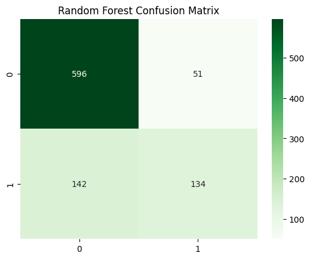

```
ROC AUC Score: 0.7033409493089622
```

```python
y_pred_rf = rf_model.predict(X_test)

print("Random Forest - Classification Report:")
print(classification_report(y_test, y_pred_rf))

sns.heatmap(confusion_matrix(y_test, y_pred_rf), annot=True, fmt='d', cmap='Greens')
plt.title("Random Forest Confusion Matrix")
plt.show()

print("ROC AUC Score:", roc_auc_score(y_test, y_pred_rf))
```

Random Forest Performance Commentary The Random Forest model achieves an accuracy of 79%, which is comparable to the pruned Decision Tree.

The ROC AUC score is 0.70, slightly lower than the pruned Decision Tree (0.72), but still acceptable.

Class-wise Performance: Class 0 (Not Converted):

Precision: 81%, Recall: 92% — excellent at identifying non-converting leads.

Confusion Matrix Breakdown: False Positives: 51 → small number of misclassified non-converters

False Negatives: 142 → higher than pruned Decision Tree (130), meaning more lost converted leads

Conclusion: While Random Forest offers ensemble stability, the default parameters don’t outperform the pruned Decision Tree in recall or AUC.

Do We Need to Prune After Using Random Forest? No, not in the traditional sense.

Random Forest is an ensemble of many decision trees (usually unpruned, deep trees).

It combats overfitting by:

Using bootstrap sampling (bagging)

Splitting on random subsets of features

Even if individual trees overfit, the ensemble averages out the variance, improving generalization.

You can still control complexity using hyperparameters:

max_depth: limit tree depth (acts like pruning)

min_samples_split, min_samples_leaf: restrict splits

n_estimators: number of trees

max_features: subset of features per split

## 9 Hyperparameter Tuning (Random Forest)

```python
#Define the Parameter Grid
param_grid = {
    'n_estimators': [100, 200],
    'max_depth': [4, 6, 8],
    'min_samples_split': [2, 5],
    'min_samples_leaf': [1, 3],
    'max_features': ['sqrt', 'log2']
}
```

```python
# Run GridSearchCV

from sklearn.model_selection import GridSearchCV

grid_rf = GridSearchCV(
    estimator=RandomForestClassifier(random_state=42),
    param_grid=param_grid,
    cv=5,
    scoring='roc_auc',
    n_jobs=-1,
    verbose=1
)

grid_rf.fit(X_train, y_train)
```

```
Fitting 5 folds for each of 48 candidates, totalling 240 fits
```

```
GridSearchCV(cv=5, estimator=RandomForestClassifier(random_state=42), n_jobs=-1,
             param_grid={'max_depth': [4, 6, 8],
                         'max_features': ['sqrt', 'log2'],
                         'min_samples_leaf': [1, 3],
                         'min_samples_split': [2, 5],
                         'n_estimators': [100, 200]},
             scoring='roc_auc', verbose=1)
```

```
Best Parameters: {'max_depth': 4, 'max_features': 'sqrt', 'min_samples_leaf': 1, 'min_samples_split': 5, 'n_estimators': 200}
Tuned Random Forest - Classification Report:
              precision    recall  f1-score   support

           0       0.80      0.96      0.87       647
           1       0.82      0.43      0.57       276

    accuracy                           0.80       923
   macro avg       0.81      0.70      0.72       923
weighted avg       0.80      0.80      0.78       923
```

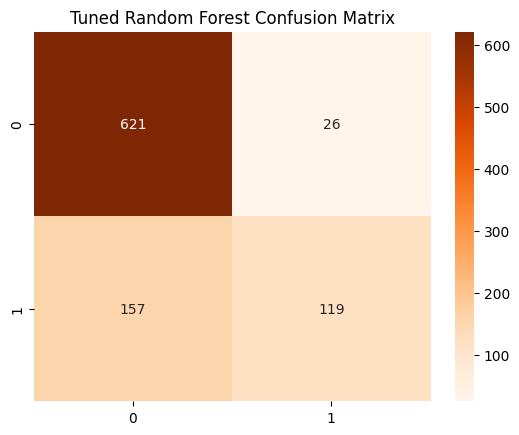

```
ROC AUC Score: 0.6954869744416817
```

```python
# Best Model Evaluation

print("Best Parameters:", grid_rf.best_params_)

best_rf = grid_rf.best_estimator_
y_pred_best = best_rf.predict(X_test)

print("Tuned Random Forest - Classification Report:")
print(classification_report(y_test, y_pred_best))

sns.heatmap(confusion_matrix(y_test, y_pred_best), annot=True, fmt='d', cmap='Oranges')
plt.title("Tuned Random Forest Confusion Matrix")
plt.show()

print("ROC AUC Score:", roc_auc_score(y_test, y_pred_best))
```

Hyperparameter Tuning – Random Forest (GridSearchCV)

Model Performance: Accuracy: 80% ROC AUC Score: 0.695

Class-wise Breakdown: Class 0 (Not Converted): Precision: 80% Recall: 96% → excellent at rejecting non-serious leads

Class 1 (Converted): Precision: 82% Recall: 43% → weak performance in catching potential converters

Confusion Matrix Observations: False Positives: 26 (very low) False Negatives: 157 (very high — bad for conversion-focused goals)

Insights: Model is highly conservative — avoids recommending non-converting leads but misses many actual converters. Good if you want high-quality leads, but not ideal if the goal is to maximize conversions.

May need: Threshold adjustment Custom scoring metric Cost-sensitive learning to balance recall vs. precision